# PBMCs from a Healthy Donor: Whole Transcriptome Analysis

Single Cell Gene Expression Dataset by Cell Ranger 4 0 0

Stefan Boeing[^1]

Compiled: May 05, 2021

Abstract

“This is the QC section. In this section basic sequencing parameters are documented. Then particles that contain only ambient RNA or dead/dying cells are identified to be removed. An estimate on doubets (GEMS containing more than one cell) is made. Finally biological biases by cell cycle or gender are evaluated and regressed out as required.”

```r
chnkPrefix <- "set.parameters."
VersionPdfExt <- VersionPdfExt <- paste0(".",chnkPrefix,"V", gsub("-", "", Sys.Date()), ".pdf")
```

## Data Preparation

### Load Design File

```r
###############################################################################
## Create biologic Metadata object                                           ##

FN <- paste0(workdir, "/design/sc.design.file.csv")

if (file.exists(FN)){
    dfObio <- read.csv(FN, header = F, stringsAsFactors = F)
}

dfObio[is.na(dfObio)] <- ""

dfObio <- dfObio[dfObio[,1] != "", ]

dfObio <- data.frame(t(dfObio), stringsAsFactors = F)

names(dfObio) <- as.vector(t(dfObio[1,]))
dfObio <- dfObio[-1,]

for (i in 1:ncol(dfObio)){
    pos <- grep("#", dfObio[,i])
    if (length(pos) > 0){
        dfObio[pos, i] <- ""
    }
}

##                                                                           ##
###############################################################################
```

```r
###############################################################################
## Create sampleDetail List                                                  ##

# type must be in c("TenX", "matrixFiles", "loomFiles", "hdf5Files")

sampleNameVec <- trimws(dfObio$sampleName)
sampleNameVec <- sampleNameVec[sampleNameVec != ""]

sampleDetailList <- list()

for (i in 1:length(sampleNameVec)){
    sampleDetailList[[sampleNameVec[i]]] <- list(
        "type" = as.vector(dfObio$type[i]),
        "gene.column" =  as.numeric(dfObio$gene.column[i]), # default 2
        "path" = as.vector(dfObio$path[i]),
        "singleCellClusterParameter" = as.numeric(dfObio$singleCellClusterParameter[1]),
        "singleCellSeuratMtCutoff" = as.numeric(dfObio$singleCellSeuratMtCutoff[i]),
        "singleCellSeuratNpcs4PCA" = as.numeric(dfObio$singleCellSeuratNpcs4PCA[1]),
        "SeuratNrnaMaxFeatures" = as.numeric(dfObio$SeuratNrnaMaxFeatures[i]),
        "SeuratNrnaMinFeatures" = as.numeric(dfObio$SeuratNrnaMinFeatures[i]),
        "limsId"= as.vector(dfObio$limsID[i]),
        "singleCellChemistry" = NULL,
        "singleCellCellrangerVersion" = NULL,
        "machine" = NULL
    )
}



##                                                                           ##
###############################################################################

###############################################################################
## dbDetailList                                                              ##
dbDetailList <- list(
    "primDataDB" = as.vector(dfObio$primDataDB[1]),
    "ref.cat.db" = as.vector(dfObio$ref.cat.db[1]),
     "db.user" = as.vector(dfObio$db.user[1]),
     "host" = as.vector(dfObio$host[1])
)
## End dbDetailList                                                          ##
###############################################################################

###############################################################################
## Project detail list                                                       ##
projectDetailList <- list(

    "folder" = as.vector(dfObio$folder[1]),

    "lab.categories.table" = as.vector(dfObio$lab.categories.table[1]), # default NULL
    "sra.id.vector" = as.vector(dfObio$sra.id.vector[1]),
    "gse.id.vector" = as.vector(dfObio$gse.id.vector[1]),
    "asf.id" = as.vector(dfObio$asf.id[1]),
    "experiment.type" = as.vector(dfObio$experiment.type[1]),
    "species" = as.vector(dfObio$species[1]),
    "release" = as.vector(dfObio$release[1]),

    "project_id" = as.vector(dfObio$project_id[1]),
    "labname" = as.vector(dfObio$labname[1]),

    "timecourse.units" = as.vector(dfObio$timecourse.units[1]),
    "count.table.headline" = as.vector(dfObio$count.table.headline[1]),
    "count.table.sidelabel" = as.vector(dfObio$count.table.headline[1]),
    "heamap.headline.text" = as.vector(dfObio$count.table.headline[1])
)
## End project detail list                                                   ##
###############################################################################

###############################################################################
## Project Parameters                                                        ##
documentationParams <- list(

    "title" = as.vector(dfObio$title[1]),
    "subtitle" =  as.vector(dfObio$subtitle[1]),
    "abstract" = as.vector(dfObio$abstract[1])

)


## Done Project Params                                                       ##
###############################################################################


###############################################################################
## Project detail list                                                       ##
if (dfObio$vars.to.regress[1] == "" | toupper(dfObio$vars.to.regress[1]) == "NULL"){
    vars.to.regress <- NULL
} else {
    vars.to.regress = dfObio$vars.to.regress[1]
}

if (toupper(as.vector(dfObio$scIntegrationMethod[1])) == "SCT"){
    intMethod = "SCT"
} else if (toupper(as.vector(dfObio$scIntegrationMethod[1])) == "STANDARD"){
    intMethod = "RNA"
} else if (toupper(as.vector(dfObio$scIntegrationMethod[1])) == "RNA"){
    intMethod = "RNA"
} else {
    stop("No valid integration method provided")
}

scDetailList <- list(
    "NtopGenes" =  as.numeric(dfObio$NtopGenes[1]),
    "singleCellClusterParameter" = as.numeric(dfObio$singleCellClusterParameter[1]),
    "singleCellClusterString" = paste0("integrated_snn_res.", as.numeric(dfObio$singleCellClusterParameter[1])),
    "scIntegrationMethod" = intMethod, #"SCT", # "SCT" or "standard"
    "scNintegrationFeatures" = as.numeric(dfObio$scNintegrationFeatures[1]),
    "primReduction" = tolower(as.vector(dfObio$primReduction[1])),
    "vars.to.regress" = vars.to.regress

)
## End project detail list                                                   ##
###############################################################################

###############################################################################
## Reference Table List                                                      ##
dfRefTab <- dfObio[,grep("referenceTableListDB", names(dfObio))]

referenceTableList = list()

if (ncol(dfRefTab) > 0){
    for (i in 1:ncol(dfRefTab)){
        referenceTableList[[as.vector(dfRefTab[1,i])]] <- as.vector(dfRefTab[2,i])

    }
## To be added: Check tables against database
}


##############################################################################
## Tables for signature enrichment                                          ##
dfRefTab <- dfObio[,grep("cellSignatureDBtable", names(dfObio))]

clusterSigEnrichmentList = list()

if (ncol(dfRefTab) > 0){
    for (i in 1:ncol(dfRefTab)){
        clusterSigEnrichmentList[[as.vector(dfRefTab[1,i])]] <- as.vector(dfRefTab[2,i])

    }
## To be added: Check tables against database
}


clusterSigEnrichmentList = list(
    "Cell Type Signatures" = "mysigdb_sc_sig",
    "Cell Type Signatures" = "cibersort_L22",
    "GO-MF" = "mysigdb_c5_MF",
    "Pathways" = "mysigdb_c2_1329_canonical_pathways",
    "Hallmarks" = "mysigdb_h_hallmarks",
    "Allen_Brain_Atlas" = "Allen_Brain_Atlas",
    "Hallmarks" = "mysigdb_h_hallmarks"
)
```

```r
    # mysigdb_sc_sig
    # cibersort_L22
    # Allen_Brain_Atlas                            |
    # CORUM                                        |
    # ChEA_2016                                    |
    # DEPOD_phosphatase_substrates                 |
    # ENCODE_TF_ChIP_seq_2015                      |
    # GO_Biological_Process_2017                   |
    #LINCS_L1000_Chem_Pert_down                   |
    #LINCS_L1000_Chem_Pert_down_backup            |
    # LINCS_L1000_Chem_Pert_up                     |
    # LINCS_L1000_Chem_Pert_up_backup              |
    # NCBI_homologene_table                        |
    # Old_CMAP_down                                |
    # Old_CMAP_up                                  |
    # SGP_from_GEO_up_down_combined                |
    # SILAC_Phosphoproteomics                      |
    # TRANSFAC_and_JASPAR_PWMs                     |
    # UK_Biobank_GWAS                              |
    # ag_lab_categories                            |
    # as_lab_categories                            |
    # bader_lab_hESC_reference                     |
    # bt_lab_categories                            |
    # cat_selection_default                        |
    # cs_lab_categories                            |
    # da_lab_categories                            |
    # es_lab_categories                            |
    # esl111_cat_reference_db_table                |
    # et_lab_categories                            |
    # exploration_categories                       |
    # fg_lab_categories                            |
    # fi_lab_categories                            |
    # gk_lab_categories                            |
    # innateDB_PPI                                 |
    # jb_lab_categories                            |
    # js_lab_categories                            |
    # kn_lab_categories                            |
    # mysigdb_c1_positional                        |
    # mysigdb_c2_1329_canonical_pathways           |
    # mysigdb_c2_KEGG                              |
    # mysigdb_c2_REACTOME                          |
    # mysigdb_c2_biocarta                          |
    # mysigdb_c2_chemical_and_genetic_pertubations |
    # mysigdb_c3_TF_targets                        |
    # mysigdb_c3_miRNA_targets
# et_lab_categories                            |
# | exploration_categories                       |
# | fg_lab_categories                            |
# | fgl391_cat_reference_db_table                |
# | fi_lab_categories                            |
# | gk_lab_categories                            |
# | innateDB_PPI                                 |
# | jb_lab_categories                            |
# | js_lab_categories                            |
# | kn_lab_categories                            |
# | mysigdb_c1_positional                        |
# | mysigdb_c2_1329_canonical_pathways           |
# | mysigdb_c2_KEGG                              |
# | mysigdb_c2_REACTOME                          |
# | mysigdb_c2_biocarta                          |
# | mysigdb_c2_chemical_and_genetic_pertubations |
# | mysigdb_c3_TF_targets                        |
# | mysigdb_c3_miRNA_targets                     |
# | mysigdb_c5_BP                                |
# | mysigdb_c5_CC                                |
# | mysigdb_c5_MF                                |
# | mysigdb_c6_oncogenic_signatures              |
# | mysigdb_c7_immunologic_signatures            |
# | mysigdb_h_hallmarks                          |
# | networkcategories                            |
# | nl_lab_categories                            |
# | pa_lab_categories                            |
# | pb_lab_categories                            |
# | pfam_interpro                                |
# | pp_lab_categories                            |
# | project_db_table                             |
# | project_db_table_backup                      |
# | project_description_table                    |
# | pt_lab_categories                            |
# | re_lab_categories                            |
# | reference_categories_db_new                  |
# | rl_lab_categories                            |
# | sb_lab_categories                            |
# | sc_lab_categories                            |
# | sl_lab_categories                            |
# | sl_lab_categories_backup                     |
# | ss_lab_categories                            |
# | st_lab_categories                            |
# | temp_categories                              |
# | vp_lab_categories                            |
# | vt_lab_categories

## Done                                                                      ##
###############################################################################

# Species has to be "mus_musculus", "homo_sapiens", "danio_rerio"
# release-86, release-89

## Create defaults ##
pos <- grep("debugReduce", names(dfObio))

if (length(pos) > 0){
    if (dfObio$debugReduce == "" | toupper(dfObio$debugReduce) == "NULL") {
         "debugReduce" <- NULL
    }  else {
        debugReduce <- as.numeric(dfObio$debugReduce[1])
    }
} else {
    debugReduce <- NULL
}




Obio = new(
    "bioLOGIC",
    clusterSigEnrichmentList = clusterSigEnrichmentList,
    documentationParams = documentationParams,
    dbDetailList = dbDetailList,
    projectDetailList = projectDetailList,
    sampleDetailList = sampleDetailList,
    referenceTableList = referenceTableList,
    scDetailList = scDetailList,
    parameterList = list(

        "debugReduce" = debugReduce, # Default NULL

        "lab.categories.table" = projectDetailList$lab.categories.table, # default NULL
        "folder" = projectDetailList$folder,
        "sra.id.vector" = "",
        "gse.id.vector" = "",
        "addDmaps" = as.vector(dfObio$addDmaps[1]),

       "lims.id"= as.vector(dfObio$asf.id[1]),
        "asf.id" = as.vector(dfObio$asf.id[1]),

        "machine" = NULL,
        "experiment.type" = projectDetailList$experiment.type,
        "species" = projectDetailList$species,
        "release" = projectDetailList$release,
        "project_id" = projectDetailList$project_id,
        "labname" = projectDetailList$labname,
        "db.user" =  dbDetailList$db.user,
        "host" = dbDetailList$host,
        "timecourse.units" = "",
        "count.table.headline" = "lg10 Expr for all Samples",
        "count.table.sidelabel" = "lg10 Expr",
        "heamap.headline.text" = "Heatmap: Row-averaged Expr",
        "loadR" = "module purge;source /camp/stp/babs/working/software/modulepath_new_software_tree_2018-08-13;module load pandoc/2.2.3.2-foss-2016b;ml R/3.6.0-foss-2016b-BABS;R;",
        "pathToSeqStorageFolder" = NULL,
        "matrixFiles" = NULL,
        "loomFiles" = NULL,
        "addFullTPMtable" = FALSE,
        "hpcMount" = "",
        "parallelProcessing" = FALSE,
        "timeseries" = FALSE,
        "NtopGenes" =  scDetailList$NtopGenes,
        "singleCellClusterParameter" = as.numeric(dfObio$singleCellClusterParameter[1]),
        "singleCellClusterString" = paste0("integrated_snn_res.", as.vector(dfObio$singleCellClusterParameter[1])),
        #"singleCellRead10XgeneColumn" = 1, # default is 2
        #"singleCellPercExpressedMinCutOff" = 10,
        #"singleCellTranscriptome"="GRCh38",
        #"singleCellChemistry" = NULL,
        #"singleCellCellrangerVersion" = NULL,
        #"singleCellSeuratMtCutoff" = singleCellSeuratMtCutoff,
        "singleCellSeuratNpcs4PCA" = as.numeric(dfObio$singleCellSeuratNpcs4PCA[1]),
        "scIntegrationMethod" = as.vector(dfObio$scIntegrationMethod[1]), # "SCT" or "standard"
        #"scNintegrationFeatures" = scDetailList$scNintegrationFeatures,
        #"SeuratNrnaMaxFeatures" = SeuratNrnaMaxFeatures,
        #"SeuratNrnaMinFeatures" = SeuratNrnaMinFeatures,
        #"primReduction" = "umap",
        #"qcReports" = list(),
        "catRefFile" = as.vector(dfObio$catRefFile[1]),
        referenceTableList = referenceTableList
```

```r
    )
)

Obio <- setMountingPoint(Obio)
Obio <- setAnalysisPaths(Obio)
Obio <- setCrickGenomeAndGeneNameTable(Obio)
Obio <- createAnalysisFolders(
    Obio,
    baseDir="/camp/stp/babs/working/boeings/Projects/",
    localBaseDir = paste0(hpc.mount, "Projects/")
)
Obio <- setDataBaseParameters(Obio)

## Create html local
## Create outputfolders ##
Obio@parameterList[["html_local_dir"]] <- paste0(Obio@parameterList$localWorkDir,"html_local", "/")
if (!dir.exists(Obio@parameterList$html_local_dir)){
    dir.create(Obio@parameterList$html_local_dir)
}


## Create outputfolders ##
Obio@parameterList[["reportFigDir"]] <- paste0(Obio@parameterList$localWorkDir,"html_local", "/report_figures/")

if (!dir.exists(Obio@parameterList$reportFigDir)){
    dir.create(Obio@parameterList$reportFigDir)
}

## Create outputfolders II ##
Obio@parameterList[["reportTableDir"]] <- paste0(Obio@parameterList$localWorkDir,"html_local", "/report_tables/")

if (!dir.exists(Obio@parameterList$reportFigDir)){
    dir.create(Obio@parameterList$reportFigDir)
}
```

### Display Design Table

````r
selVec <- c(
    "sampleName",
    names(dfObio)[grep("META_", toupper(names(dfObio)))],
    dfObio$limsID,
    "type",
    "singleCellSeuratMtCutoff",
    "SeuratNrnaMinFeatures",
    "SeuratNrnaMaxFeatures"
)

selVec <- selVec[selVec %in% names(dfObio)]
dfDesign <- unique(dfObio[,selVec])
dfDesign <- data.frame(t(dfDesign))
orderVec <- names(dfDesign)

dfDesign[["Column"]] <- row.names(dfDesign)
dfDesign <- dfDesign[,c("Column", orderVec)]

if (length(grep("sampleName", row.names(dfDesign))) > 0){
    names(dfDesign) <- as.vector(t(dfDesign["sampleName",]))
    pos <- grep("sampleName", row.names(dfDesign))
    dfDesign <- dfDesign[-pos, ]
}

## Remove empty columns ##
rmVec <- as.vector(NULL, mode = "numeric")
for (i in 1:ncol(dfDesign)){
    tempVec <- unique(dfDesign[,i])
    if (length(tempVec) == 1 & tempVec[1] == ""){
        rmVec <- c(
            rmVec,
            i
        )
    }
}

if (length(rmVec) > 0){
    dfDesign <- dfDesign[,-rmVec]
}


#tabDownloadLink <- paste0("The quality measures table can be downloaded [here](",FNrel,")")

tabLegend = paste0(
    "**Table: ",tableCount,"** Sample definition table"
)

tableCount <- tableCount + 1

chnkVec <- paste0(
        #"#### ", names(dtList),
        "\n```{r sample_defenition_table, results='asis', echo=F, eval=TRUE, warning=FALSE, fig.cap='",
        tabLegend,"'}\n",
        "\n",
        "\n DT::datatable(dfDesign,rownames = FALSE,  escape = FALSE)",
        "\n cat(  '\n')",
        "\n\n\n```\n"
    )
````

### Sample Definition Table

```r
if (exists("dfRes")){
    cat(paste(knitr::knit(text = chnkVec, quiet = T), collapse = '\n'))

}
```

| sampleName | PBMC10X |
| --- | --- |
| type | TenX |
| singleCellSeuratMtCutoff | 15 |
| SeuratNrnaMinFeatures | 1000 |
| SeuratNrnaMaxFeatures | 10000 |

**Table: 1** Sample definition table

```r
chnkPrefix <- "create.10X.QC.table."
VersionPdfExt <- VersionPdfExt <- paste0(".",chnkPrefix,"V", gsub("-", "", Sys.Date()), ".pdf")
```

````r
###############################################################################
## Create 10X QC table                                                       ##


tableCreated <- FALSE
sampleNames <- names(Obio@sampleDetailList)
cmdDocuVec <- as.vector(NULL, mode = "character")

for (i in 1:length(sampleNames)){
    if (Obio@sampleDetailList[[sampleNames[i]]]$type == "TenX"){
        baseFN <- Obio@sampleDetailList[[sampleNames[i]]]$path
        summaryFN <- gsub("filtered_feature_bc_matrix", "metrics_summary.csv", baseFN)
        if (file.exists(summaryFN)){
            dfTemp <- read.csv(summaryFN)
            dfTemp[["sampleName"]] <- sampleNames[i]
            if (!tableCreated){
                tableCreated = TRUE
                dfRes <- dfTemp
            } else {
                dfRes <- rbind(
                    dfRes,
                    dfTemp
                )
            }
        }

        cmdFN <- paste0(
            gsub(
                "outs/filtered_feature_bc_matrix",
                "",
                Obio@sampleDetailList[[i]]$path
            ),
            "_cmdline"
        )

        if (file.exists(cmdFN)){
                dfCMD <- read.delim(
                    cmdFN,
                    header = F
                )
                cmdAddVec <- c(
                        paste0("**",names(Obio@sampleDetailList)[i],"**"),
                        "\n",
                        as.vector(dfCMD[1,1]),
                        "\n",
                        "\n"

                )
                cmdDocuVec <- c(cmdDocuVec, cmdAddVec)
        }
    }
}

if (exists("dfRes")){
dfRes <- data.frame(t(dfRes))
colVec <- as.vector(t(dfRes["sampleName",]))
names(dfRes) <- colVec


dfRes[["Parameter"]] <- row.names(dfRes)
dfRes <- dfRes[!(row.names(dfRes) %in% c("sampleName")),]
row.names(dfRes) <- NULL
colVec <- c("Parameter", colVec)
dfRes <- dfRes[,colVec]
dfRes$Parameter <- gsub("[.]", " ", dfRes$Parameter)


###############################################################################
## Write table to Excel File                                                 ##

createXLSXoutput(
    dfTable = dfRes,
    outPutFN = paste0(Obio@parameterList$reportTableDir ,Obio@parameterList$project_id, "_QC_Parameter_Table.xlsx"),
    tableName = paste0(Obio@parameterList$project_id, "_QC_Parameter_Table")
)

## Done creating Excel output table                                          ##
###############################################################################


FNbase <- paste0(Obio@parameterList$project_id, "_QC_Parameter_Table.xlsx")
FN <- paste0(Obio@parameterList$reportTableDir, FNbase)
FNrel <- paste0("report_tables/", FNbase)


tabDownloadLink <- paste0("The quality measures table can be downloaded [here](",FNrel,")")

tabLegend = paste0(
    "**Table: ** QC Parameters for all 10X single-cell samples in this experiment. ",
    tabDownloadLink
)

chnkVec <- paste0(
        #"#### ", names(dtList),
        "\n```{r QC_datatable, results='asis', echo=F, eval=TRUE, warning=FALSE, fig.cap='",
        tabLegend,"'}\n",
        "\n",
        "\n DT::datatable(dfRes,rownames = FALSE,  escape = FALSE)",
        "\n cat(  '\n')",
        "\n\n\n```\n"
    )
    tabVar <- "### Create QC Table"
}   else {
    tabVar <- ""
}
````

[1] “Table saved as /camp/stp/babs/working/boeings/Projects/boeings/stefan.boeing/426_scRNAseq_PBMC_10k/workdir/html_local/report_tables/PBMC10k_QC_Parameter_Table.xlsx.”

```r
## Make CMD section ##
if (exists("cmdDocuVec") & length(cmdDocuVec) > 0){
    cellRangerVar <- "### CellRanger Count Commands"
} else {
    cellRangerVar <- ""
}
## Done creating one table per cluster                                      ##
##############################################################################
```

### CellRanger Count Commands

[1] “**PBMC10X**” [1] “” [1] “/camp/apps/misc/stp/babs/manual/software/c/cellranger-3.0.2/cellranger-cs/3.0.2/bin/count –id=PBMC10X –transcriptome=/camp/svc/reference/Genomics/10x/10x_transcriptomes/GRCh38-3.0.0_GFP-tdT/ –fastqs=/camp/stp/babs/working/boeings/Projects/boeings/stefan.boeing/426_scRNAseq_PBMC_10k/FASTQ_files –sample=Parent_NGSC3_DI_PBMC” [1] “” [1] “”

### Create QC Table

```r
if (exists("dfRes")){
    cat(paste(knitr::knit(text = chnkVec, quiet = T), collapse = '\n'))

}
```

| Parameter | PBMC10X |
| --- | --- |
| Estimated Number of Cells | 10,185 |
| Mean Reads per Cell | 69,920 |
| Median Genes per Cell | 2,056 |
| Number of Reads | 712,144,074 |
| Valid Barcodes | 98.3% |
| Sequencing Saturation | 74.0% |
| Q30 Bases in Barcode | 95.6% |
| Q30 Bases in RNA Read | 92.5% |
| Q30 Bases in Sample Index | 95.3% |
| Q30 Bases in UMI | 95.3% |

[output cut: 10 more lines]

**Table:** QC Parameters for all 10X single-cell samples in this experiment. The quality measures table can be downloaded here

```r
###############################################################################
## Create Cell Ranger QC Plots                                               ##
if (exists("dfRes")){
## Add if clause to check 10X
resList <- doCRplots(
    obj = Obio,
    figureCount = figureCount,
    VersionPdfExt = VersionPdfExt,
    tocSubLevel = 4,
    dotsize = 0.5
)

plotListQC1 <- resList$plotListQC1
chnkVec <- resList$chnkVec
figureCount <- resList$figureCount
    if (length(plotListQC1) > 3){

        tabVar <- "### CellRanger QC {.tabset .tabset-fade .tabset-dropdown}"
    } else {

        tabVar <- "### CellRanger QC {.tabset .tabset-fade .tabset-pills}"
    }



} else {
    tabVar <- ""
}

## Done create cellRanger QC plots                                           ##
###############################################################################
```

### CellRanger QC

```r
if (exists("dfRes")){
cat(paste(knitr::knit(text = chnkVec, quiet = T), collapse = '\n'))
}
```

#### PBMC10X

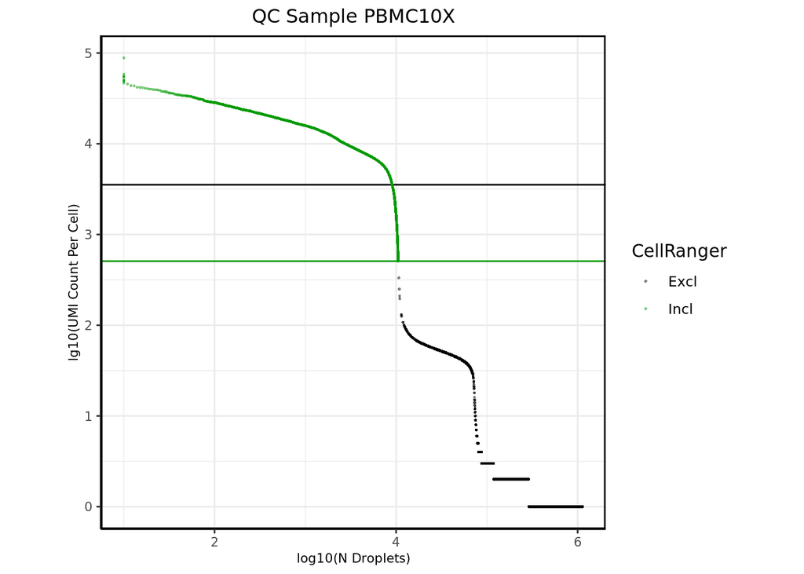

**Figure 1:** CellRanger quality assessment. Green cells are considered for further analysis. Download a pdf of this figure here.

#### All

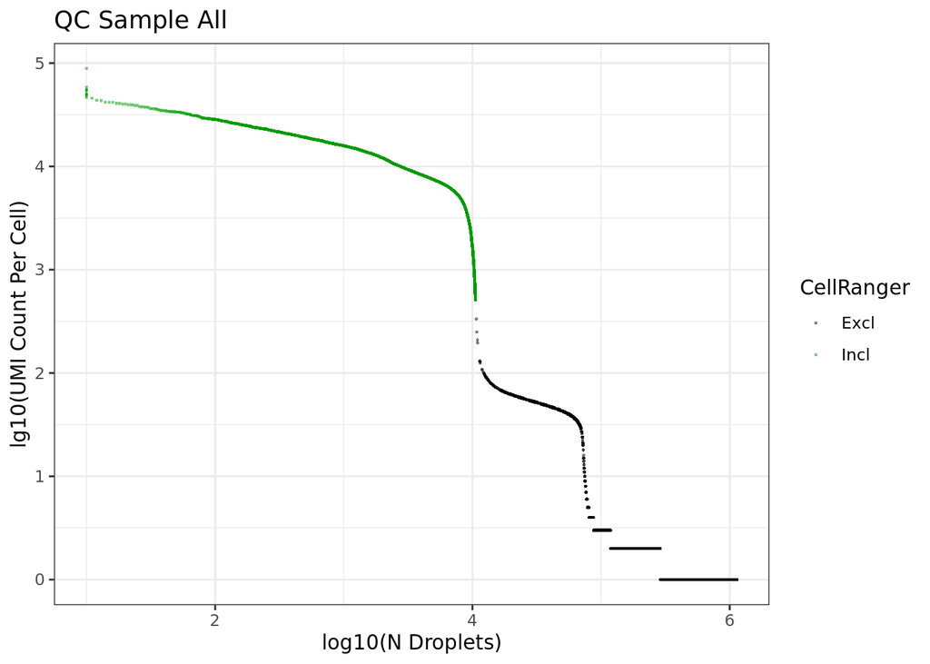

**Figure 2:** CellRanger quality assessment. Green cells are considered for further analysis. Download a pdf of this figure here.

```r
chnkPrefix <- "QC.A.create.sample.list."
VersionPdfExt <- VersionPdfExt <- paste0(".",chnkPrefix,"V", gsub("-", "", Sys.Date()), ".pdf")
```

```r
###############################################################################
## Create Sample List QC                                                     ##

SampleList <- createSampleListQC(
    obj = Obio,
    reduce = Obio@parameterList$debugReduce,
    vars.to.regress = Obio@scDetailList$vars.to.regress,
    s.genes = NULL,
    g2m.genes = NULL
)
```

[1] “Retrieved category: S_Phase_Genes_Seurat” [1] "Retrieved category ID: ag_lab_categories__41" [1] “Retrieved category: G2M_Phase_Genes_Seurat” [1] "Retrieved category ID: ag_lab_categories__42" Modularity Optimizer version 1.3.0 by Ludo Waltman and Nees Jan van Eck

Number of nodes: 10185 Number of edges: 360986

Running Louvain algorithm… Maximum modularity in 10 random starts: 0.9396 Number of communities: 15 Elapsed time: 1 seconds

```r
if (is.null(Obio@parameterList$debugReduce)){
    debugReducOutput <- "Full Dataset"
} else {
    debugReducOutput <- paste0(Obio@parameterList$debugReduce * 100, "% of all cells used.")
}

print(cat(paste0("Cell Recuction: ", Obio@parameterList$debugReduce)))
```

Cell Recuction: NULL

```r
lapply(SampleList, dim)
```

$PBMC10X [1] 18889 10185

```r
if (is.null(Obio@scDetailList$vars.to.regress)){
    stringVar <- "### Regressed-out Variables /n No regression was applied to input single-cell samples before integration."
} else {
    stringVar <- paste0("### Regressed-out Variables /n Regression for parameter ", Obio@parameterList$vars.to.regress, " was used on the individual single-cell samples before integration.")
}

## Done                                                                      ##
###############################################################################
```

```r
chnkPrefix <- "QC.A.create.sample.level.QC.plots."
VersionPdfExt <- VersionPdfExt <- paste0(".",chnkPrefix,"V", gsub("-", "", Sys.Date()), ".pdf")
```

```r
###############################################################################
## Do percent mt plots                                                       ##
resList <- doPercMT_plotSL(
        SampleList = SampleList,
        obj = Obio,
        figureCount = figureCount,
        VersionPdfExt = ".pdf",
        tocSubLevel = 4
)


plotListRF <- resList$plotListRF
chnkVec <- resList$chnkVec
figureCount <- resList$figureCount

## Done create cellRanger QC plots                                           ##
###############################################################################

if (length(plotListRF) > 3){
    tabVar <- ".tabset .tabset-fade .tabset-dropdown"
} else {
    tabVar <- ".tabset .tabset-fade .tabset-pills"
}
```

### Create PercentMT Historgrams Plots

```r
cat(paste(knitr::knit(text = chnkVec, quiet = T), collapse = '\n'))
```

#### Hist_MT_PBMC10X

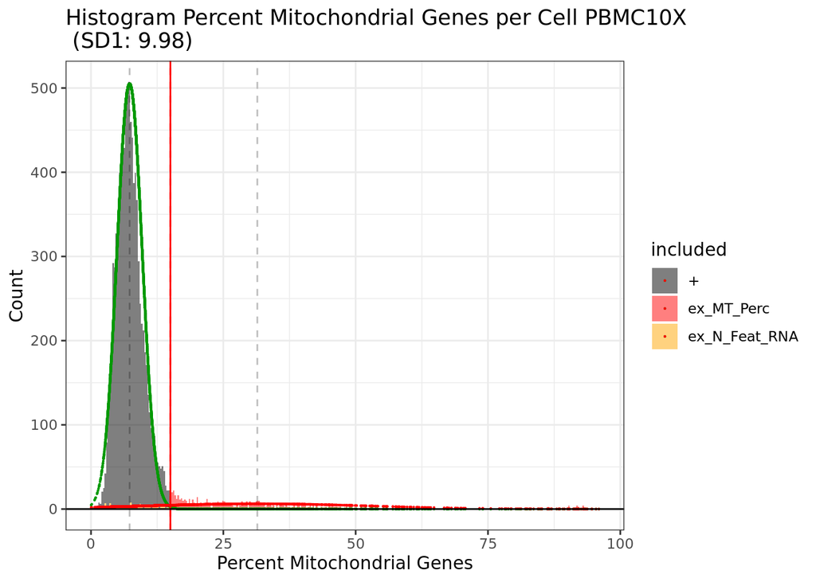

**Figure 3C:** Histogram depicting percent mitochondrial genes for each sample PBMC10X. Download a pdf of this figure here.

```r
###############################################################################
## Do percent mt plots                                                       ##
resList <- doRNAfeat_plotSL(
        SampleList,
        obj = Obio,
        figureCount = figureCount,
        VersionPdfExt = ".pdf",
        tocSubLevel = 4
)

plotListRF <- resList$plotListRF
chnkVec <- resList$chnkVec
figureCount <- resList$figureCount

## Done create cellRanger QC plots                                           ##
###############################################################################

if (length(plotListRF) > 3){
    tabVar <- ".tabset .tabset-fade .tabset-dropdown"
} else {
    tabVar <- ".tabset .tabset-fade .tabset-pills"
}
```

### Create RNA Feature Historgrams Plots

```r
cat(paste(knitr::knit(text = chnkVec, quiet = T), collapse = '\n'))
```

#### PBMC10X

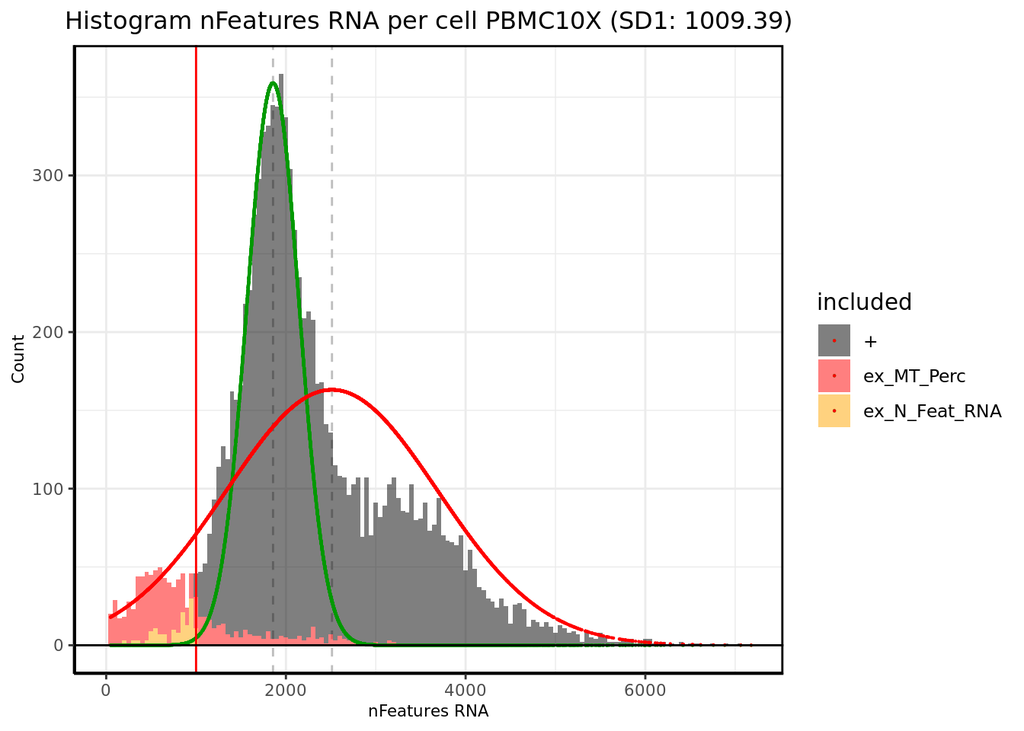

**Figure 4C:** Histogram depicting genes found per cell/nuclei for sample PBMC10X. Download a pdf of this figure here.

```r
###############################################################################
## Do percent mt plots                                                       ##
resList <- doUMAP_plotSL(
        SampleList,
        obj = Obio,
        figureCount = figureCount,
        VersionPdfExt = ".pdf",
        tocSubLevel = 4,
        dotsize = 0.5
)

plotListSQCUMAP <- resList$plotListSQCUMAP
chnkVec <- resList$chnkVec
figureCount <- resList$figureCount

## Done create cellRanger QC plots                                           ##
###############################################################################

if (length(plotListSQCUMAP) > 3){
    tabVar <- ".tabset .tabset-fade .tabset-dropdown"
} else {
    tabVar <- ".tabset .tabset-fade .tabset-pills"
}
```

### Plot UMAP Per Sample

```r
cat(paste(knitr::knit(text = chnkVec, quiet = T), collapse = '\n'))
```

#### U_PBMC10X

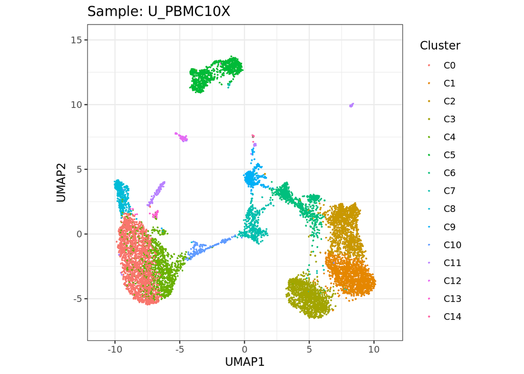

**Figure 5:** Sample-level UMAP plot for QC purposes. Download a pdf of this figure here.

```r
###############################################################################
## Do percent mt plots                                                       ##
resList <- doUMAP_cellCyle(
        SampleList,
        obj = Obio,
        figureCount = figureCount,
        VersionPdfExt = ".pdf",
        tocSubLevel = 4,
        dotsize = 0.5,
        cellCycleRefFile = paste0(hpc.mount, "Projects/reference_data/cell_cycle_vignette_files/nestorawa_forcellcycle_expressionMatrix.txt")
)


plotList <- resList$plotList
chnkVec <- resList$chnkVec
figureCount <- resList$figureCount

## Done create cellRanger QC plots                                           ##
###############################################################################


if (length(plotList) > 3){
    tabVar <- ".tabset .tabset-fade .tabset-dropdown"
} else {
    tabVar <- ".tabset .tabset-fade .tabset-pills"
}
```

### Plot Cell Cycle UMAP Per Sample

```r
cat(paste(knitr::knit(text = chnkVec, quiet = T), collapse = '\n'))
```

#### UMAP_Cell_Cycle_Plot_PBMC10X

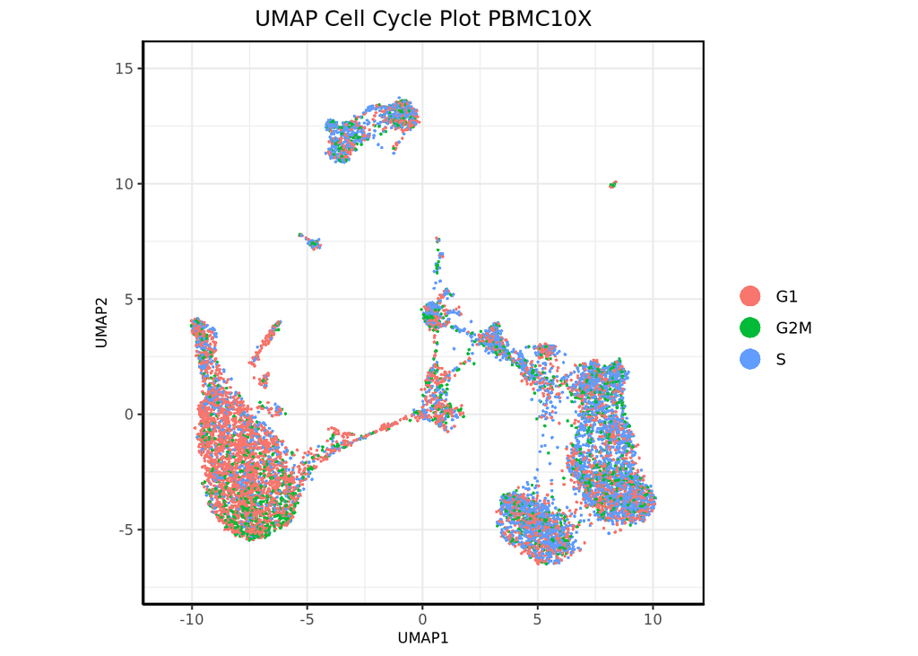

**Figure 6:** Sample-level UMAPs. Estimated cell-cylce phase color-coded. Download a pdf of this figure here.

```r
###############################################################################
## Do percent mt plots                                                       ##
resList <- doCellCycleBarchart(
        SampleList,
        obj = Obio,
        figureCount = figureCount,
        VersionPdfExt = ".pdf",
        tocSubLevel = 4,
        cellCycleRefFile = paste0(hpc.mount, "Projects/reference_data/cell_cycle_vignette_files/nestorawa_forcellcycle_expressionMatrix.txt")
)

plotList <- resList$plotList
chnkVec <- resList$chnkVec
figureCount <- resList$figureCount

## Done create cellRanger QC plots                                           ##
###############################################################################

if (length(plotList) > 3){
    tabVar <- ".tabset .tabset-fade .tabset-dropdown"
} else {
    tabVar <- ".tabset .tabset-fade .tabset-pills"
}
```

### Plot Per Sample Cell Cycle Estimate

```r
cat(paste(knitr::knit(text = chnkVec, quiet = T), collapse = '\n'))
```

#### CellCycle_Barchart_Ncells

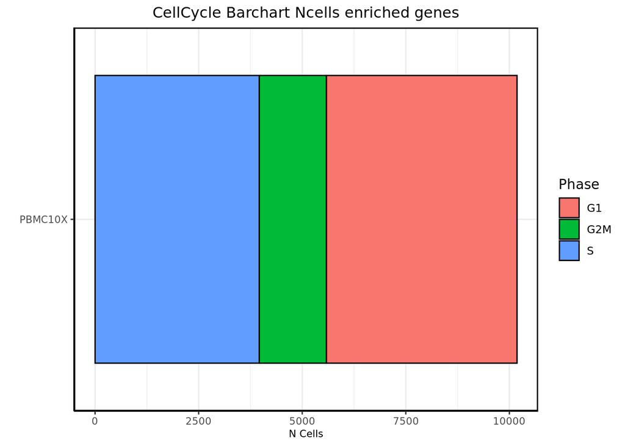

**Figure 7:** Sample-level cell cycle estimates. Download a pdf of this figure here.

#### CellCycle_Barchart_Percent_Cells

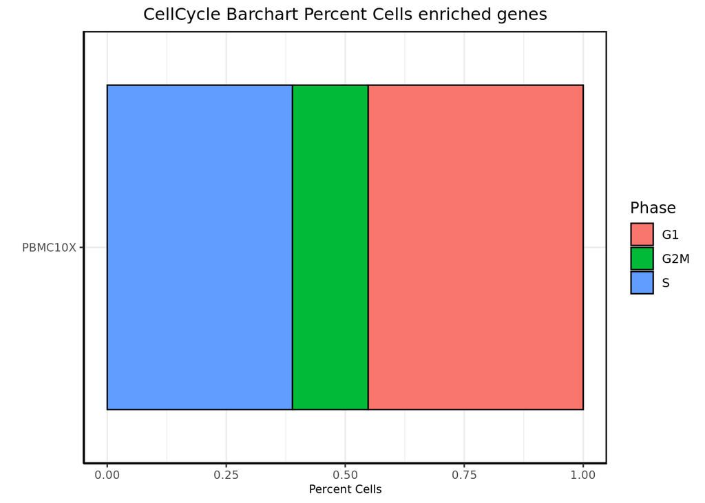

**Figure 8:** Sample-level cell cycle estimates. Download a pdf of this figure here.

```r
if (!exists("runDoubletFinder")){
    runDoubletFinder <- TRUE
}

tabVar <- ""
```

{}

```r
###############################################################################
## Do percent mt plots                                                       ##

resList <- doUMAP_plot_percMT(
    SampleList,
    obj =  Obio,
    figureCount = figureCount,
    VersionPdfExt = ".pdf",
    tocSubLevel = 4,
    dotsize = 0.5
)


plotListUMT <- resList$plotListUMT
chnkVec <- resList$chnkVec
figureCount <- resList$figureCount


## Done create cellRanger QC plots                                           ##
###############################################################################

if (length(plotListUMT) > 3){
    tabVar <- ".tabset .tabset-fade .tabset-dropdown"
} else {
    tabVar <- ".tabset .tabset-fade .tabset-pills"
}
```

### Plot Per Sample MT Percentage

```r
cat(paste(knitr::knit(text = chnkVec, quiet = T), collapse = '\n'))
```

#### UMT_PBMC10X

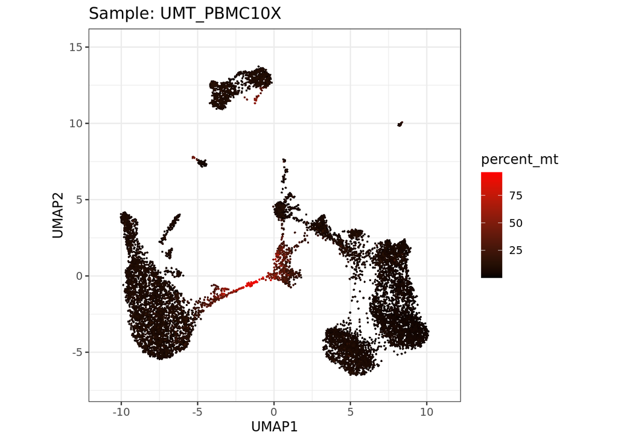

**Figure 9:** Sample-level UMAP plot for QC purposes. Colored by the percent of mitochondrial gene expression per cell. Download a pdf of this figure here.

```r
###############################################################################
## Do percent mt plots                                                       ##

resList <- doUMAP_plot_nFeatRNA(
    SampleList,
    obj =  Obio,
    figureCount = figureCount,
    VersionPdfExt = ".pdf",
    tocSubLevel = 4,
    dotsize = 0.5
)


plotListNC <- resList$plotListNC
chnkVec <- resList$chnkVec
figureCount <- resList$figureCount


## Done create cellRanger QC plots                                           ##
###############################################################################

if (length(plotListNC) > 3){
    tabVar <- ".tabset .tabset-fade .tabset-dropdown"
} else {
    tabVar <- ".tabset .tabset-fade .tabset-pills"
}
```

### Plot Per Sample nFeatures RNA

```r
cat(paste(knitr::knit(text = chnkVec, quiet = T), collapse = '\n'))
```

#### NC_PBMC10X

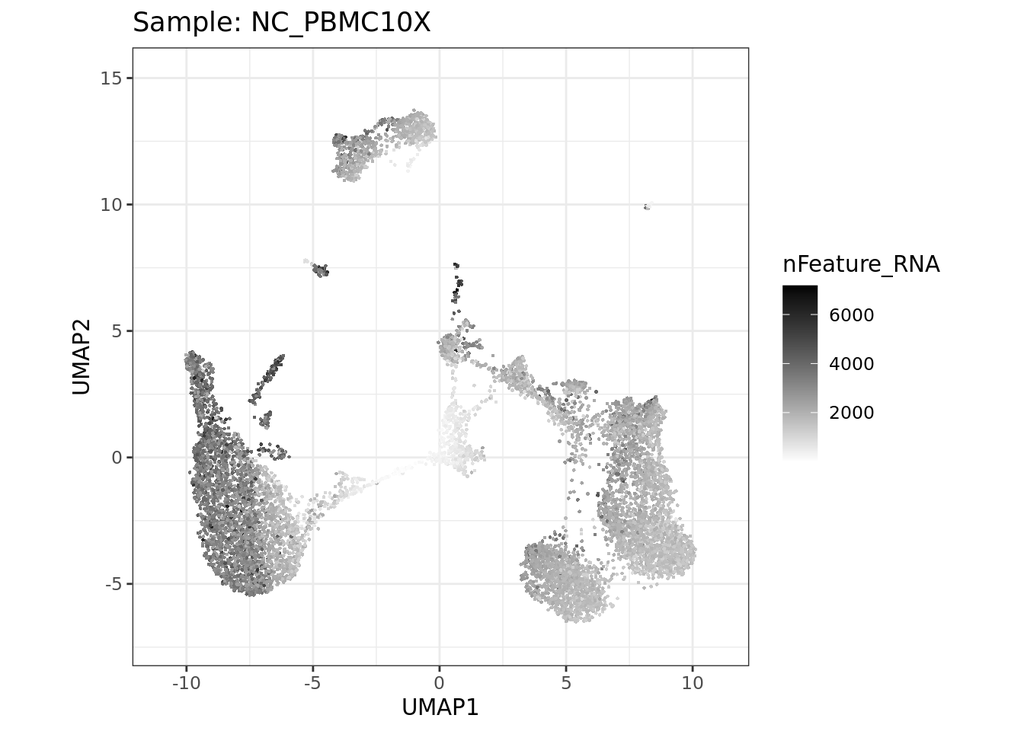

**Figure 10:** Sample-level UMAP plot for QC purposes. Colored by the nFeatureRNA number. Download a pdf of this figure here.

```r
### Will save Obio object here, so it can be re-used with different parameters
save(Obio,
     file = paste0(
         Obio@parameterList$localWorkDir,
         Obio@parameterList$project_id,
         ".bioLOGIC.Robj"
     )
)

print("R bioLOGIC single cell object initialized.")
```

## Documentation

```r
## Try to retrieve project data from db ##
library(RMySQL)
db.pwd2 <- "_asf_"
db.user2 <- "asf"
host2 <- "ms1.thecrick.org"
projectParams <- Obio@documentationParams

tryCatch({
    dbDB = dbConnect(drv = RMySQL::MySQL(), user = db.user2, password = db.pwd2, host = host2, dbname = "asf");
dfProposal =  dbGetQuery(dbDB, paste0("SELECT * FROM asf_proposals WHERE project_name ='",Obio@parameterList$lims.id,"'"));
dbDisconnect(dbDB)
  }, error = function(x) {
    message("Project Database could not be reached or has no entry in Obio@parameterList$lims.id for this analysis.")

})

if (exists("dfProposal")){
    if (!is.na(dfProposal[1,"ProjectAlias"]) & dfProposal[1,"ProjectAlias"] != ""){
        projectParams[["title"]] = paste0(dfProposal[1,"ProjectAlias"], " - ", dfProposal[1,"project_name"])
    }

    if (!is.na(dfProposal[1,"project_user"]) & dfProposal[1,"project_user"] != ""){
        projectParams[["subtitle"]] = paste0(dfProposal[1,"user_lab"], " Lab - ", dfProposal[1,"project_user"])
        projectParams[["subtitle"]] <- gsub("^ Lab - ", "", projectParams[["subtitle"]])

    }

    if (!is.na(dfProposal[1,"proposal_text"]) & dfProposal[1,"proposal_text"] != ""){
        projectParams[["abstract"]] = dfProposal[1,"proposal_text"]


    }
}

## Escape all special characters
projectParams <- lapply(
  projectParams, function(x)
  #gsub("([.|()\\^{}+$*?]|\\[|\\])", "\\\\\1", x)
  gsub("([.|()/\\^{}+$*?]|\\[|\\])", " ", x)
)

projectParams <- lapply(
  projectParams, function(x)
  #gsub("([.|()\\^{}+$*?]|\\[|\\])", "\\\\\1", x)
  gsub("\\\n", " ", x)
)


#projectParams$title <- "Title"
projectParams$abstract <- "This is the QC section. In this section basic sequencing parameters are documented. Then particles that contain only ambient RNA or dead/dying cells are identified to be removed. An estimate on doubets (GEMS containing more than one cell) is made. Finally biological biases by cell cycle or gender are evaluated and regressed out as required."
#projectParams$subtitle <- "Abstract"
```

[^1]: The Francis Crick Institute, stefan.boeing@crick.ac.uk